# Assignment 4

Manning Smith

2024-10-12

## Data Dictionary of the dataset

- ID: Subject Identifier
- ALIVE: 1–infant alive; 2—infant not alive;
- BF5EVER: Breastfeed–ever, 1=No, 2=Yes.
- BF5LNGTH: duration – length of time in weeks
- PGWT_GN: Pregnant weight gain/lost
- MOM_CM: Moms height – centimeters
- MOM_BMI: MOM BODY MASS INDEX
- MOMCIG: Number of Cigarettes Per Day
- CIG_PRIOR : No. of cigarettes smoked - prior to pregnant
- MOM_LBKG : Moms weight – before pregnant

## Import Data

```r
pramData <- read.csv("PRAMSZZSept.csv")

#View(pramData)
```

```r
summary(pramData)
```

```
##       ID                MOMCIG          MOM_LBKG        BF5EVER
##  Length:189159      Min.   : 0.000   Min.   :  2.0   Min.   :1.000
##  Class :character   1st Qu.: 0.000   1st Qu.:125.0   1st Qu.:2.000
##  Mode  :character   Median : 0.000   Median :143.0   Median :2.000
##                     Mean   : 0.956   Mean   :151.7   Mean   :1.836
##                     3rd Qu.: 0.000   3rd Qu.:170.0   3rd Qu.:2.000
##                     Max.   :98.000   Max.   :466.0   Max.   :2.000
##                     NA's   :7001     NA's   :3895    NA's   :6733
##     BF5LNGTH         MOM_BMI           ALIVE         CIG_PRIOR
##  Min.   : 1.00    Min.   :  0.35   Min.   :1.00    Min.   : 0.00
##  1st Qu.: 2.00    1st Qu.: 21.46   1st Qu.:1.00    1st Qu.: 0.00
##  Median : 3.00    Median : 24.41   Median :1.00    Median : 0.00
##  Mean   : 7.06    Mean   : 26.07   Mean   :1.01    Mean   : 1.76
##  3rd Qu.: 6.00    3rd Qu.: 29.18   3rd Qu.:1.00    3rd Qu.: 0.00
##  Max.   :41.00    Max.   :116.05   Max.   :2.00    Max.   :98.00
##  NA's   :120603   NA's   :9566     NA's   :58576   NA's   :63707
##      MOM_CM          PGWT_GN
##  Min.   :119.0    Min.   :  0.0
##  1st Qu.:157.0    1st Qu.: 20.0
##  Median :163.0    Median : 30.0
##  Mean   :163.1    Mean   : 31.4
##  3rd Qu.:168.0    3rd Qu.: 40.0
##  Max.   :410.0    Max.   :323.0
##  NA's   :120278   NA's   :123922
```

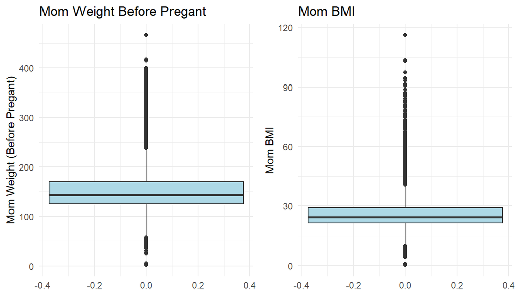

```r
p1 <- ggplot(pramData, aes(x = as.factor(ALIVE))) +
  geom_bar(fill = "skyblue") +
  labs(x = "Alive (1 = Alive, 2 = Dead)", y = "Frequency", title = "Alive Frequency") +
  theme_minimal()

p2 <- ggplot(pramData, aes(y = MOM_LBKG)) +
  geom_boxplot(fill = "lightblue") +
  labs(y = "Mom Weight (Before Pregant)", title = "Mom Weight Before Pregant") +
  theme_minimal()

p3 <- ggplot(pramData, aes(y = MOM_BMI)) +
  geom_boxplot(fill = "lightblue") +
  labs(y = "Mom BMI", title = "Mom BMI") +
  theme_minimal()

p4 <- ggplot(pramData, aes(y = CIG_PRIOR)) +
  geom_boxplot(fill = "lightblue") +
  labs(y = "Cigarettes Smoked", title = "Cigarettes Smoked Before Pregant") +
  theme_minimal()


grid.arrange(p2, p3, ncol = 2, nrow = 1)
```

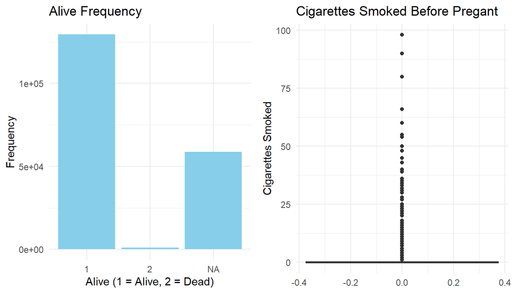

```r
grid.arrange(p1, p4, ncol = 2, nrow = 1)
```

# Part 1

**Missing data is defined as the values or data that is not stored/not present for some variable/s in the given dataset.**  
- Identify types of Missing Values - Brief describe the methods to handle missing values in a dataset

There are three types of missing values. MCAR, MAR, and NMAR. - MCAR: Missing Completely at Random. These missing values occur in no pattern and have no relation to any of the other values of a variable. This is often the rarest type of missing value. - MAR: Missing at Random. This is a little different being, can be further explained by already known or obtained data. - NAMR: Not missing at Random. The conclusion can be made if the missing values fit neither of the other discussed categories. Implying, there there could be a reason the values are missing or the value is missing because another value provides a reason for a missing value.

```r
colSums(is.na(pramData))
```

```
##        ID    MOMCIG  MOM_LBKG   BF5EVER  BF5LNGTH   MOM_BMI     ALIVE CIG_PRIOR
##         0      7001      3895      6733    120603      9566     58576     63707
##    MOM_CM   PGWT_GN
##    120278    123922
```

# Part 2

## Question 1

**“ALIVE” is a variable indicting if the infant was alive or not when the participant answered the survey. ALIVE: 1–infant alive; 2: infant not alive. There are a lot of missing for “ALIVE” in the survey. It is impossible for you to get back to double check the participants about the survival status of infants with missing values.Please suggest a reasonable way to handle the missing values for variable “ALIVE”. (hint: USA infant mortality in the 21st century ).**

One possibility to handle the missing values for the `ALIVE` variable would be to use the suggested UAS infant mortality rates and extrapolate this information onto the values for our data. Utilizing a tool provided by macrotrends.net, cited here:https://www.macrotrends.net/global-metrics/countries/USA/united-states/infant-mortality-rate. We can find the average mortality rate of infants in the United States form $2009$ to $2013$.

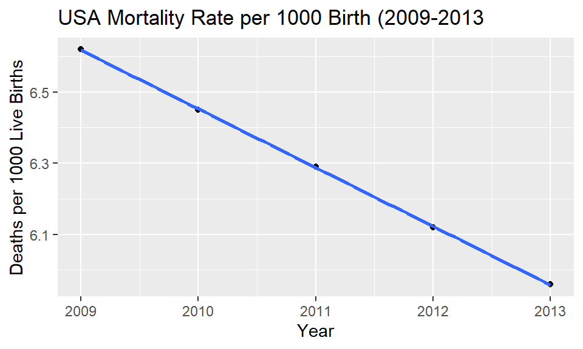

```r
years <- 2009:2013
values <- c(6.62, 6.45, 6.29, 6.12, 5.96)

usaMortality <- data.frame(Year = years, Value = values)

ggplot(usaMortality, aes(x = Year, y = Value)) +
  geom_point() +
  labs(x = "Year", y = "Deaths per 1000 Live Births", title = "USA Mortality Rate per 1000 Birth (2009-2013") +
  geom_smooth(method = "lm", se = FALSE)
```

```r
avgMortality <- mean(usaMortality$Value)
```

The average infant mortality rate was 6.29 during the timeframe this data was collected.

```r
sumAlive_1 <- sum(as.integer(pramData$ALIVE) == 1, na.rm = TRUE)
sumAlive_2 <- sum(as.integer(pramData$ALIVE) == 2, na.rm = TRUE)
sumAlive <- sumAlive_1 + sumAlive_2

# Mortality Rate of the Dataset per 1000 births
dataMorRate <- (sumAlive_2 / sumAlive) * 1000
```

The mortality rate for the provided data in our dataset is higher than that of the USA average, thus there are probably a plenty of unreported alive births. For the sake of analysis we will utilize the average mortality rate provided by the source above.

## Question 2

**Examine variables with zero variance or near-zero variance.**

```r
nzv <- nearZeroVar(pramData, saveMetrics = TRUE)
nzv$zeroVar == TRUE
```

```
##  [1] FALSE FALSE FALSE FALSE FALSE FALSE FALSE FALSE FALSE FALSE
```

```r
kable(nzv, caption = "Zero / Non-Zero Variance", col.names = c("Freq Ratio", "Percent Unique", "Zero Variance", "Non Zero Variance"), align = 'c')
```

Zero / Non-Zero Variance

|  | Freq Ratio | Percent Unique | Zero Variance | Non Zero Variance |
| --- | --- | --- | --- | --- |
| ID | 1.000000 | 100.0000000 | FALSE | FALSE |
| MOMCIG | 33.341639 | 0.0290761 | FALSE | TRUE |
| MOM_LBKG | 1.132192 | 0.1903161 | FALSE | FALSE |
| BF5EVER | 5.094070 | 0.0010573 | FALSE | FALSE |
| BF5LNGTH | 1.262253 | 0.0179743 | FALSE | FALSE |
| MOM_BMI | 1.022497 | 1.6319604 | FALSE | FALSE |
| ALIVE | 122.075401 | 0.0010573 | FALSE | TRUE |
| CIG_PRIOR | 22.038508 | 0.0248468 | FALSE | TRUE |
| MOM_CM | 1.158987 | 0.0343626 | FALSE | FALSE |
| PGWT_GN | 1.371763 | 0.1189476 | FALSE | FALSE |

There are no variables with zero variance, but there are some variables with non-zero variance.  
`MOMCIG`, `ALIVE`, and `CIG_Prior` all were identified as non-zero variance.

## Question 3

**Using the “cor” function (both parametric and non-parametric methods) to explore the correlation matrix among the variables, and visualize the correlation matrix (download “corrplot” package or other R package).**

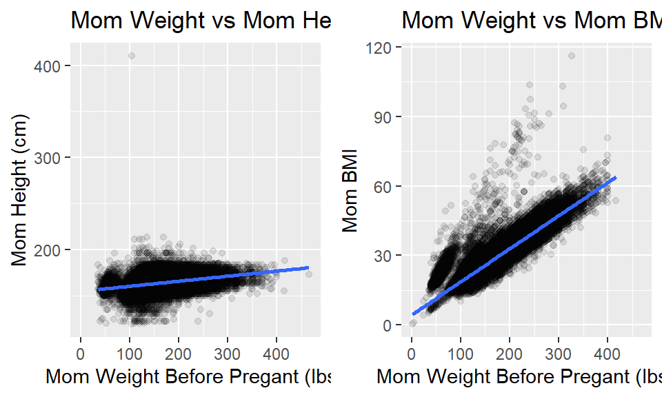

```r
p1 <- ggplot(pramData, aes(x = MOM_LBKG, y = MOM_CM)) +
  geom_point(alpha = 0.1) +
  labs(x = "Mom Weight Before Pregant (lbs)", y = "Mom Height (cm)", title = "Mom Weight vs Mom Height") +
  geom_smooth(method = "lm", se = FALSE)

p2 <- ggplot(pramData, aes(x = MOM_LBKG, y = MOM_BMI)) +
  geom_point(alpha = 0.1) +
  labs(x = "Mom Weight Before Pregant (lbs)", y = "Mom BMI", title = "Mom Weight vs Mom BMI") +
  geom_smooth(method = "lm", se = FALSE)

grid.arrange(p1, p2, ncol = 2, nrow = 1)
```

```r
cor_pears <- cor(pramData[, -1], method = "pearson")

cor_spear <- cor(pramData[, -1], method = "spearman")
highCorr <- caret::findCorrelation(abs(cor_spear), cutoff = 0.95)
```

## Question 4

**Explore the missing values in the data set.**

*a) Using complete.cases() function to get percentage of missing value.*

```r
total_rows <- nrow(pramData)
sumCC <- sum(complete.cases(pramData))
perct_missing <- (total_rows - sumCC) / total_rows * 100
```

The percentage of missing values is 91.008. This means that over $90$% of the rows in this dataset of atleast one missing value in it.

*b) Using md.pattern function to identify which variables and what percentage of observations from each variable are missing; using plot.missing() function to get the visualization of missing values and to identify variables that may need attention.*

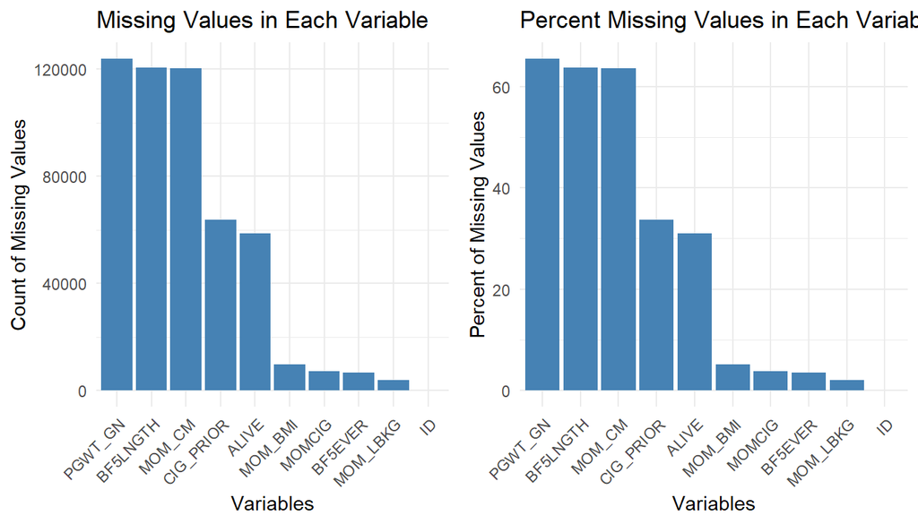

```r
md_pattern <- md.pattern(pramData[, -1], plot=FALSE, rotate.names = TRUE)

#plot(mice::md.pattern(pramData))

# Create a summary of missing values
missing_info <- data.frame(Variables = names(pramData),
                           Missing = colSums(is.na(pramData)),
                           PercentMissing = colSums(is.na(pramData)) / nrow(pramData) * 100)

# Create a bar plot of missing values
p1 <- ggplot(missing_info, aes(x = reorder(Variables, -Missing), y = Missing)) +
  geom_bar(stat = "identity", fill = "steelblue") +
  labs(title = "Missing Values in Each Variable",
       x = "Variables",
       y = "Count of Missing Values") +
  theme_minimal() +
  theme(axis.text.x = element_text(angle = 45, hjust = 1))

p2 <- ggplot(missing_info, aes(x = reorder(Variables, -Missing), y = PercentMissing)) +
  geom_bar(stat = "identity", fill = "steelblue") +
  labs(title = "Percent Missing Values in Each Variable",
       x = "Variables",
       y = "Percent of Missing Values") +
  theme_minimal() +
  theme(axis.text.x = element_text(angle = 45, hjust = 1))

grid.arrange(p1, p2, ncol = 2, nrow = 1)
```

*c) Using suitable method to conduct the imputation for handling missing values in the data set, and showing part of the imputed results.*

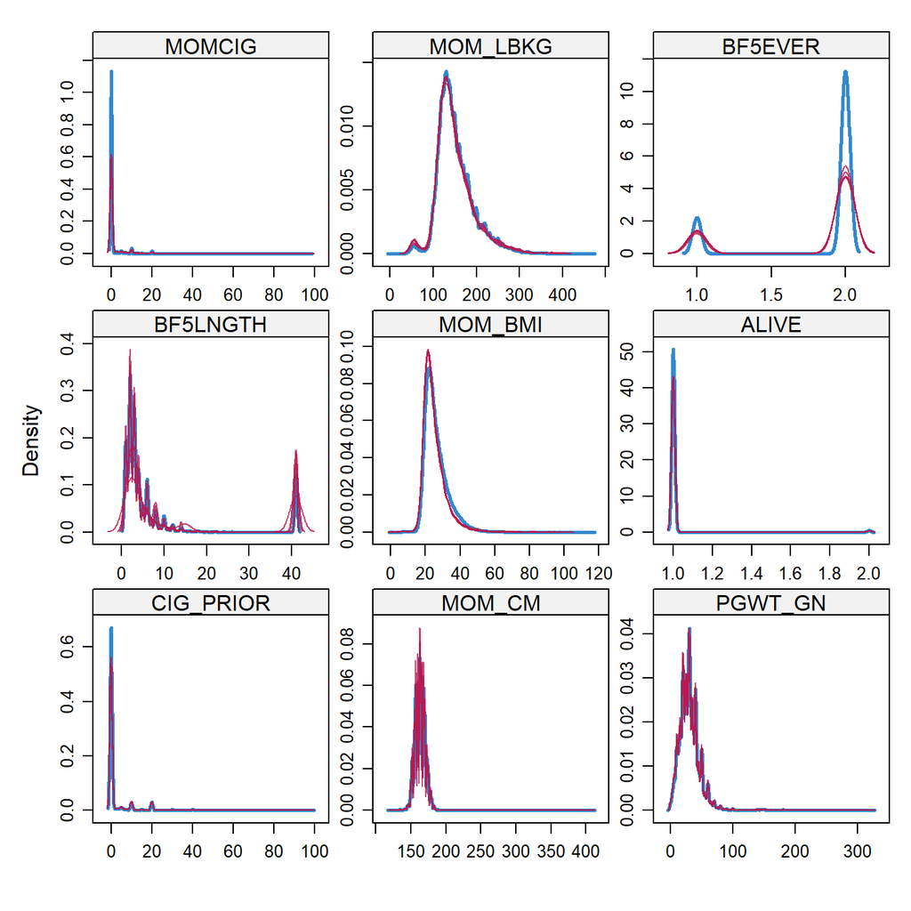

```r
#marginplot(pramData[,c("ALIVE", "BF5LNGTH")], col = mdc(1:2), cex.numbers = 1.2, pch=19)
mice_imputes <- mice(pramData, m=5, maxit=5)
densityplot(mice_imputes)
```